# 3주차 패키지

위재성

# Chapter 1 모델링을 위한 전처리

## 문제0. (기본 세팅) 패키지를 불러오고 디렉토리를 설정하세요요.

```r
setwd("C:/Users/위재성/Desktop/Psat/2학기/Package/3주차 패키지")

need_packages <- c("tidyverse", "data.table", 'caret', 'magrittr')
options(warn = -1)
for(i in 1:length(need_packages)){
  if(require(need_packages[i], character.only = T) == 0){
    install.packages(need_packages[i])
    require(need_packages[i], character.only = T)
  }
  else{require(need_packages[i], character.only = T)}
}
rm(list = ls())
```

## 문제1. train.csv와 test.csv 데이터의 기본 구조를 파악하고 변수 와 데이터 개수, 결측치 여부를 확인하세요.

```r
# 데이터 불러오기
data = fread('train.csv', data.table = F)
test = fread('test.csv', data.table = F)

# train 데이터 파악
data %>% head(3)
```

```
##   gender car reality child_num income_total          income_type
## 1      F   N       N         0       202500 Commercial associate
## 2      M   Y       Y         0       450000              Working
## 3      F   N       Y         0       202500 Commercial associate
##                        edu_type family_type          house_type DAYS_BIRTH
## 1              Higher education     Married Municipal apartment     -13899
## 2              Higher education     Married   House / apartment     -19087
## 3 Secondary / secondary special     Married   House / apartment     -15088
##   DAYS_EMPLOYED FLAG_MOBIL work_phone phone email  occyp_type family_size
## 1         -4709          1          0     0     0                       2
## 2         -4434          1          0     1     0    Managers           2
## 3         -2092          1          0     1     0 Sales staff           2
##   begin_month credit
## 1          -6      0
## 2         -22      1
## 3         -37      0
```

```r
data %>% glimpse()
```

```
## Rows: 21,166
## Columns: 19
## $ gender        <chr> "F", "M", "F", "F", "F", "M", "M", "F", "F", "F", "F", "~
## $ car           <chr> "N", "Y", "N", "Y", "N", "N", "Y", "N", "N", "Y", "N", "~
## $ reality       <chr> "N", "Y", "Y", "Y", "Y", "Y", "Y", "Y", "Y", "Y", "N", "~
## $ child_num     <int> 0, 0, 0, 0, 2, 0, 1, 0, 0, 1, 0, 0, 2, 0, 0, 0, 0, 0, 0,~
## $ income_total  <dbl> 202500, 450000, 202500, 157500, 270000, 270000, 180000, ~
## $ income_type   <chr> "Commercial associate", "Working", "Commercial associate~
## $ edu_type      <chr> "Higher education", "Higher education", "Secondary / sec~
## $ family_type   <chr> "Married", "Married", "Married", "Married", "Married", "~
## $ house_type    <chr> "Municipal apartment", "House / apartment", "House / apa~
## $ DAYS_BIRTH    <int> -13899, -19087, -15088, -15037, -13413, -14896, -15131, ~
## $ DAYS_EMPLOYED <int> -4709, -4434, -2092, -2105, -4996, -5420, -1466, -1308, ~
## $ FLAG_MOBIL    <int> 1, 1, 1, 1, 1, 1, 1, 1, 1, 1, 1, 1, 1, 1, 1, 1, 1, 1, 1,~
## $ work_phone    <int> 0, 0, 0, 0, 0, 0, 0, 0, 1, 0, 0, 0, 0, 0, 0, 0, 0, 0, 0,~
## $ phone         <int> 0, 1, 1, 0, 0, 0, 0, 0, 1, 0, 1, 1, 1, 1, 0, 0, 1, 1, 0,~
## $ email         <int> 0, 0, 0, 0, 1, 1, 1, 0, 1, 0, 0, 0, 0, 0, 1, 0, 0, 0, 0,~
## $ occyp_type    <chr> "", "Managers", "Sales staff", "Managers", "High skill t~
## $ family_size   <int> 2, 2, 2, 2, 4, 2, 3, 2, 1, 3, 2, 1, 4, 2, 2, 2, 2, 2, 2,~
## $ begin_month   <int> -6, -22, -37, -26, -18, -53, -38, -5, -40, -60, -41, -41~
## $ credit        <int> 0, 1, 0, 1, 0, 0, 1, 1, 1, 0, 1, 1, 0, 0, 1, 1, 1, 1, 0,~
```

```r
data %>% summary()
```

```
##     gender              car              reality            child_num
##  Length:21166       Length:21166       Length:21166       Min.   : 0.0000
##  Class :character   Class :character   Class :character   1st Qu.: 0.0000
##  Mode  :character   Mode  :character   Mode  :character   Median : 0.0000
##                                                           Mean   : 0.4266
##                                                           3rd Qu.: 1.0000
##                                                           Max.   :14.0000
##   income_total     income_type          edu_type         family_type
##  Min.   :  27000   Length:21166       Length:21166       Length:21166
##  1st Qu.: 121500   Class :character   Class :character   Class :character
##  Median : 157500   Mode  :character   Mode  :character   Mode  :character
##  Mean   : 187639
##  3rd Qu.: 225000
##  Max.   :1575000
##   house_type          DAYS_BIRTH     DAYS_EMPLOYED        FLAG_MOBIL
##  Length:21166       Min.   :-25140   Min.   :-15713.0   Min.   :1
##  Class :character   1st Qu.:-19431   1st Qu.: -3153.0   1st Qu.:1
##  Mode  :character   Median :-15537   Median : -1550.0   Median :1
##                     Mean   :-15962   Mean   : 59071.8   Mean   :1
##                     3rd Qu.:-12454   3rd Qu.:  -410.5   3rd Qu.:1
##                     Max.   : -7723   Max.   :365243.0   Max.   :1
##    work_phone         phone            email          occyp_type
##  Min.   :0.0000   Min.   :0.0000   Min.   :0.00000   Length:21166
##  1st Qu.:0.0000   1st Qu.:0.0000   1st Qu.:0.00000   Class :character
##  Median :0.0000   Median :0.0000   Median :0.00000   Mode  :character
##  Mean   :0.2262   Mean   :0.2959   Mean   :0.09085
##  3rd Qu.:0.0000   3rd Qu.:1.0000   3rd Qu.:0.00000
##  Max.   :1.0000   Max.   :1.0000   Max.   :1.00000
##   family_size      begin_month         credit
##  Min.   : 1.000   Min.   :-60.00   Min.   :0.0000
##  1st Qu.: 2.000   1st Qu.:-39.00   1st Qu.:0.0000
##  Median : 2.000   Median :-24.00   Median :1.0000
##  Mean   : 2.194   Mean   :-26.14   Mean   :0.6396
##  3rd Qu.: 3.000   3rd Qu.:-12.00   3rd Qu.:1.0000
##  Max.   :15.000   Max.   :  0.00   Max.   :1.0000
```

```r
data %>% is.na %>% colSums()
```

```
##        gender           car       reality     child_num  income_total
##             0             0             0             0             0
##   income_type      edu_type   family_type    house_type    DAYS_BIRTH
##             0             0             0             0             0
## DAYS_EMPLOYED    FLAG_MOBIL    work_phone         phone         email
##             0             0             0             0             0
##    occyp_type   family_size   begin_month        credit
##             0             0             0             0
```

```r
# test 데이터 파악
test %>% head(3)
```

```
##   gender car reality child_num income_total          income_type
## 1      F   N       Y         1       247500 Commercial associate
## 2      F   N       N         0       315000              Working
## 3      M   Y       Y         1       135000 Commercial associate
##                        edu_type    family_type        house_type DAYS_BIRTH
## 1 Secondary / secondary special Civil marriage House / apartment     -11380
## 2 Secondary / secondary special      Separated House / apartment     -17570
## 3              Higher education        Married House / apartment     -11759
##   DAYS_EMPLOYED FLAG_MOBIL work_phone phone email occyp_type family_size
## 1         -1540          1          0     0     1   Laborers           3
## 2         -1978          1          0     0     1 Core staff           1
## 3           -91          1          0     0     0   Managers           3
##   begin_month
## 1          -5
## 2         -41
## 3         -51
```

```r
test %>% glimpse()
```

```
## Rows: 5,291
## Columns: 18
## $ gender        <chr> "F", "F", "M", "F", "M", "M", "M", "F", "F", "F", "F", "~
## $ car           <chr> "N", "N", "Y", "N", "N", "Y", "Y", "Y", "N", "N", "N", "~
## $ reality       <chr> "Y", "N", "Y", "Y", "Y", "Y", "Y", "Y", "N", "Y", "Y", "~
## $ child_num     <int> 1, 0, 1, 0, 0, 0, 2, 0, 1, 0, 0, 0, 0, 0, 0, 0, 0, 0, 1,~
## $ income_total  <dbl> 247500, 315000, 135000, 180000, 202500, 585000, 112500, ~
## $ income_type   <chr> "Commercial associate", "Working", "Commercial associate~
## $ edu_type      <chr> "Secondary / secondary special", "Secondary / secondary ~
## $ family_type   <chr> "Civil marriage", "Separated", "Married", "Married", "Ma~
## $ house_type    <chr> "House / apartment", "House / apartment", "House / apart~
## $ DAYS_BIRTH    <int> -11380, -17570, -11759, -13727, -19200, -16653, -13022, ~
## $ DAYS_EMPLOYED <int> -1540, -1978, -91, -6031, -346, -1646, -1600, -3482, -42~
## $ FLAG_MOBIL    <int> 1, 1, 1, 1, 1, 1, 1, 1, 1, 1, 1, 1, 1, 1, 1, 1, 1, 1, 1,~
## $ work_phone    <int> 0, 0, 0, 0, 0, 0, 0, 0, 0, 0, 1, 0, 0, 1, 1, 0, 1, 1, 0,~
## $ phone         <int> 0, 0, 0, 0, 1, 0, 0, 0, 0, 1, 0, 0, 0, 1, 1, 0, 1, 1, 0,~
## $ email         <int> 1, 1, 0, 0, 0, 0, 0, 0, 0, 0, 0, 0, 1, 1, 0, 0, 0, 0, 0,~
## $ occyp_type    <chr> "Laborers", "Core staff", "Managers", "", "High skill te~
## $ family_size   <int> 3, 1, 3, 2, 2, 2, 4, 2, 3, 2, 2, 2, 2, 1, 2, 2, 2, 2, 3,~
## $ begin_month   <int> -5, -41, -51, -7, -30, -8, -39, -48, -2, -25, -10, -14, ~
```

```r
test %>% summary()
```

```
##     gender              car              reality            child_num
##  Length:5291        Length:5291        Length:5291        Min.   : 0.000
##  Class :character   Class :character   Class :character   1st Qu.: 0.000
##  Mode  :character   Mode  :character   Mode  :character   Median : 0.000
##                                                           Mean   : 0.437
##                                                           3rd Qu.: 1.000
##                                                           Max.   :19.000
##   income_total    income_type          edu_type         family_type
##  Min.   : 27000   Length:5291        Length:5291        Length:5291
##  1st Qu.:121500   Class :character   Class :character   Class :character
##  Median :157500   Mode  :character   Mode  :character   Mode  :character
##  Mean   :185977
##  3rd Qu.:225000
##  Max.   :990000
##   house_type          DAYS_BIRTH     DAYS_EMPLOYED      FLAG_MOBIL
##  Length:5291        Min.   :-25152   Min.   :-15072   Min.   :1
##  Class :character   1st Qu.:-19431   1st Qu.: -3141   1st Qu.:1
##  Mode  :character   Median :-15570   Median : -1508   Median :1
##                     Mean   :-15941   Mean   : 59057   Mean   :1
##                     3rd Qu.:-12411   3rd Qu.:  -393   3rd Qu.:1
##                     Max.   : -7705   Max.   :365243   Max.   :1
##    work_phone         phone            email          occyp_type
##  Min.   :0.0000   Min.   :0.0000   Min.   :0.00000   Length:5291
##  1st Qu.:0.0000   1st Qu.:0.0000   1st Qu.:0.00000   Class :character
##  Median :0.0000   Median :0.0000   Median :0.00000   Mode  :character
##  Mean   :0.2189   Mean   :0.2875   Mean   :0.09299
##  3rd Qu.:0.0000   3rd Qu.:1.0000   3rd Qu.:0.00000
##  Max.   :1.0000   Max.   :1.0000   Max.   :1.00000
##   family_size      begin_month
##  Min.   : 1.000   Min.   :-60.00
##  1st Qu.: 2.000   1st Qu.:-39.00
##  Median : 2.000   Median :-24.00
##  Mean   : 2.207   Mean   :-26.07
##  3rd Qu.: 3.000   3rd Qu.:-12.00
##  Max.   :20.000   Max.   :  0.00
```

```r
test %>% is.na %>% colSums()
```

```
##        gender           car       reality     child_num  income_total
##             0             0             0             0             0
##   income_type      edu_type   family_type    house_type    DAYS_BIRTH
##             0             0             0             0             0
## DAYS_EMPLOYED    FLAG_MOBIL    work_phone         phone         email
##             0             0             0             0             0
##    occyp_type   family_size   begin_month
##             0             0             0
```

## 문제2. character 형태로 되어있는 변수들을 factor 형태로 바꾸세요.

```r
data %<>% mutate_if(is.character, factor)
data %>% glimpse()
```

```
## Rows: 21,166
## Columns: 19
## $ gender        <fct> F, M, F, F, F, M, M, F, F, F, F, F, M, M, M, F, M, F, F,~
## $ car           <fct> N, Y, N, Y, N, N, Y, N, N, Y, N, N, Y, N, N, N, N, N, N,~
## $ reality       <fct> N, Y, Y, Y, Y, Y, Y, Y, Y, Y, N, Y, Y, Y, N, Y, N, N, N,~
## $ child_num     <int> 0, 0, 0, 0, 2, 0, 1, 0, 0, 1, 0, 0, 2, 0, 0, 0, 0, 0, 0,~
## $ income_total  <dbl> 202500, 450000, 202500, 157500, 270000, 270000, 180000, ~
## $ income_type   <fct> Commercial associate, Working, Commercial associate, Sta~
## $ edu_type      <fct> Higher education, Higher education, Secondary / secondar~
## $ family_type   <fct> Married, Married, Married, Married, Married, Married, Ma~
## $ house_type    <fct> Municipal apartment, House / apartment, House / apartmen~
## $ DAYS_BIRTH    <int> -13899, -19087, -15088, -15037, -13413, -14896, -15131, ~
## $ DAYS_EMPLOYED <int> -4709, -4434, -2092, -2105, -4996, -5420, -1466, -1308, ~
## $ FLAG_MOBIL    <int> 1, 1, 1, 1, 1, 1, 1, 1, 1, 1, 1, 1, 1, 1, 1, 1, 1, 1, 1,~
## $ work_phone    <int> 0, 0, 0, 0, 0, 0, 0, 0, 1, 0, 0, 0, 0, 0, 0, 0, 0, 0, 0,~
## $ phone         <int> 0, 1, 1, 0, 0, 0, 0, 0, 1, 0, 1, 1, 1, 1, 0, 0, 1, 1, 0,~
## $ email         <int> 0, 0, 0, 0, 1, 1, 1, 0, 1, 0, 0, 0, 0, 0, 1, 0, 0, 0, 0,~
## $ occyp_type    <fct> , Managers, Sales staff, Managers, High skill tech staff~
## $ family_size   <int> 2, 2, 2, 2, 4, 2, 3, 2, 1, 3, 2, 1, 4, 2, 2, 2, 2, 2, 2,~
## $ begin_month   <int> -6, -22, -37, -26, -18, -53, -38, -5, -40, -60, -41, -41~
## $ credit        <int> 0, 1, 0, 1, 0, 0, 1, 1, 1, 0, 1, 1, 0, 0, 1, 1, 1, 1, 0,~
```

## 문제3. 변수 의미 txt파일을 참고하여 남은 범주형 변수들도 factor 형태로 바꾼 뒤 str을 확인해주세요.

```r
# 소유 여부를 나타내는 변수들과 credit 변수를 범주화
cols = c('FLAG_MOBIL','work_phone','phone','email','credit')
data[cols] %<>% apply(2,as.factor)
data %<>% mutate_if(is.character, factor)
data %>% str()
```

```
## 'data.frame':    21166 obs. of  19 variables:
##  $ gender       : Factor w/ 2 levels "F","M": 1 2 1 1 1 2 2 1 1 1 ...
##  $ car          : Factor w/ 2 levels "N","Y": 1 2 1 2 1 1 2 1 1 2 ...
##  $ reality      : Factor w/ 2 levels "N","Y": 1 2 2 2 2 2 2 2 2 2 ...
##  $ child_num    : int  0 0 0 0 2 0 1 0 0 1 ...
##  $ income_total : num  202500 450000 202500 157500 270000 ...
##  $ income_type  : Factor w/ 5 levels "Commercial associate",..: 1 5 1 3 5 1 1 5 5 1 ...
##  $ edu_type     : Factor w/ 5 levels "Academic degree",..: 2 2 5 2 5 5 2 5 5 5 ...
##  $ family_type  : Factor w/ 5 levels "Civil marriage",..: 2 2 2 2 2 2 2 2 3 2 ...
##  $ house_type   : Factor w/ 6 levels "Co-op apartment",..: 3 2 2 2 2 2 2 2 2 2 ...
##  $ DAYS_BIRTH   : int  -13899 -19087 -15088 -15037 -13413 -14896 -15131 -15785 -19063 -11938 ...
##  $ DAYS_EMPLOYED: int  -4709 -4434 -2092 -2105 -4996 -5420 -1466 -1308 -2213 -2162 ...
##  $ FLAG_MOBIL   : Factor w/ 1 level "1": 1 1 1 1 1 1 1 1 1 1 ...
##  $ work_phone   : Factor w/ 2 levels "0","1": 1 1 1 1 1 1 1 1 2 1 ...
##  $ phone        : Factor w/ 2 levels "0","1": 1 2 2 1 1 1 1 1 2 1 ...
##  $ email        : Factor w/ 2 levels "0","1": 1 1 1 1 2 2 2 1 2 1 ...
##  $ occyp_type   : Factor w/ 19 levels "","Accountants",..: 1 12 16 12 7 6 1 13 10 2 ...
##  $ family_size  : int  2 2 2 2 4 2 3 2 1 3 ...
##  $ begin_month  : int  -6 -22 -37 -26 -18 -53 -38 -5 -40 -60 ...
##  $ credit       : Factor w/ 2 levels "0","1": 1 2 1 2 1 1 2 2 2 1 ...
```

## 문제4. Factor형 형태의 변수들의 각 level이 몇 개인지 개수를 확인하고 다음과 같이 그래프를 그려주세요.

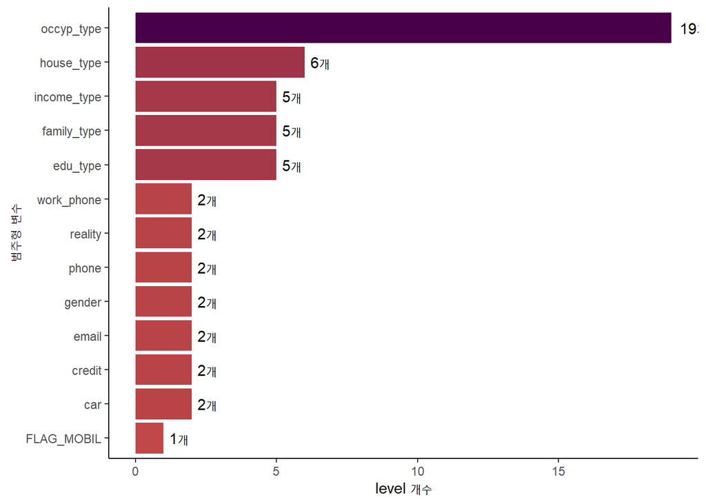

```r
# 각 변수들의 level 개수 확인
n_level = data %>% select(where(is.factor)) %>% sapply(n_distinct)

data.frame(n_level,var = names(n_level), row.names=NULL) %>% # 데이터 프레임화

  # ggplot 시작
  ggplot(aes(x = n_level, y = reorder(var, n_level), fill = n_level)) +
  geom_col() +
  geom_text(aes(label = paste(n_level, '개', sep = '')), hjust= -0.3) +

  # 테마 수정
  theme_classic() +
  labs(x = 'level 개수', y = '범주형 변수') +
  scale_fill_gradient(low = '#C04848', high = '#480048') +
  theme(legend.position = 'None')
```

## 문제4-1. 그래프를 통해 필요 없는 변수를 확인하고 삭제하세요.

```r
# FLAG_MOBIL의 경우 level의 개수가 1개이므로 삭제
data %<>% select(-FLAG_MOBIL)
```

## 문제5. days_birth는 데이터 생성일로부터 며칠 전 태어났는지를 역으로 세는 변수입니다. (-1은 데이터 수집일 하루 전에 태어났음을 의미) 이 변수를 사용하여 나이(AGE) 파생변수를 생성하고 기존 변수는 삭제하세요. (반올림 사용 가능)

```r
data %<>%
  mutate(age = round(-DAYS_BIRTH / 365)) %>% # 365일로 나눠준뒤 반올림
  select(-DAYS_BIRTH) # 기존 변수 삭제
data$age
```

[output not shown]

[output cut: 867 more lines]

## 문제6. days_employed는 데이터 생성일로부터 며칠 전 업무를 시작했는지를 나타내는 변 수입니다. (-1은 데이터 수집일 하루 전부터 일을 시작했음을 의미, 다만 양수 값은 고용되지 않은 상태를 뜻함) 이 변수를 사용하여 업무 년차(YEARS_EMPLOYED) 파생변수를 생성하고 기존 변수는 삭제하세요.

```r
data %<>%
  mutate(years_employed =
           ifelse(DAYS_EMPLOYED > 0, 0, floor(-DAYS_EMPLOYED / 365))) %>% # 365일로 나눠준뒤 버림
  select(-DAYS_EMPLOYED) # 기존 변수 삭제

data$years_employed
```

[output not shown]

[output cut: 867 more lines]

## 문제7. Test 데이터셋도 같은 방식으로 전처리 해주세요.

```r
test = fread('test.csv', data.table = F)

cols = c('FLAG_MOBIL','work_phone','phone','email')
test[cols] %<>% apply(2,as.factor)

test %<>%
  mutate_if(is.character, factor) %>%
  select(-FLAG_MOBIL) %>%

  mutate(age = round(-DAYS_BIRTH / 365)) %>%
  select(-DAYS_BIRTH) %>%

  mutate(years_employed =
           ifelse(DAYS_EMPLOYED > 0, 0, floor(-DAYS_EMPLOYED / 365))) %>%
  select(-DAYS_EMPLOYED)
```

## 문제8. train 데이터를 학습용 데이터와 검증용 데이터로 분리하세요.

(p=0.8, seed:123)

```r
set.seed(123)
train_idx = createDataPartition(p=0.8,list = F, y = data$credit)
train = data[train_idx,]
valid = data[-train_idx,]
```

# Chapter 2 분류모델: 로지스틱 회귀

```r
library(glmnet)
library(Epi)
library(MLmetrics)
```

## 문제1-1. 전체 변수들을 가지고 로지스틱 회귀 모델을 만들고 결과를 보여주세요.

```r
fit = glm(credit ~ ., data = train, family = binomial)
summary(fit)
```

```
##
## Call:
## glm(formula = credit ~ ., family = binomial, data = train)
##
## Deviance Residuals:
##     Min       1Q   Median       3Q      Max
## -2.1768  -1.2594   0.7855   0.9734   1.6739
##
## Coefficients:
##                                         Estimate Std. Error z value Pr(>|z|)
## (Intercept)                           -1.422e+00  1.121e+00  -1.268  0.20486
## genderM                                5.004e-03  4.352e-02   0.115  0.90846
## carY                                   2.523e-02  3.746e-02   0.673  0.50067
## realityY                              -1.177e-01  3.690e-02  -3.189  0.00143
## child_num                             -3.412e-01  4.749e-01  -0.719  0.47245
## income_total                           4.108e-07  1.798e-07   2.285  0.02230
## income_typePensioner                  -2.097e-01  8.335e-02  -2.516  0.01186
## income_typeState servant              -7.199e-02  7.047e-02  -1.022  0.30700
## income_typeStudent                    -1.591e+00  1.238e+00  -1.285  0.19881
## income_typeWorking                    -1.064e-01  4.199e-02  -2.535  0.01125
## edu_typeHigher education               1.245e-01  5.330e-01   0.234  0.81534
## edu_typeIncomplete higher              3.085e-01  5.390e-01   0.572  0.56704
## edu_typeLower secondary                5.755e-01  5.599e-01   1.028  0.30398
## edu_typeSecondary / secondary special  2.452e-01  5.326e-01   0.460  0.64517
## family_typeMarried                     1.548e-01  6.085e-02   2.544  0.01097
## family_typeSeparated                   5.670e-01  4.828e-01   1.175  0.24017
## family_typeSingle / not married        4.896e-01  4.783e-01   1.024  0.30595
## family_typeWidow                       3.158e-01  4.849e-01   0.651  0.51495
## house_typeHouse / apartment            2.210e-01  2.475e-01   0.893  0.37182
## house_typeMunicipal apartment          3.570e-01  2.640e-01   1.352  0.17627
## house_typeOffice apartment             7.572e-02  3.199e-01   0.237  0.81292
## house_typeRented apartment            -2.640e-01  2.776e-01  -0.951  0.34155
## house_typeWith parents                 2.349e-01  2.584e-01   0.909  0.36338
## work_phone1                           -3.089e-02  4.366e-02  -0.708  0.47922
## phone1                                 1.541e-02  3.810e-02   0.404  0.68592
## email1                                 1.738e-01  5.883e-02   2.955  0.00313
## occyp_typeAccountants                 -2.091e-01  9.905e-02  -2.111  0.03475
## occyp_typeCleaning staff               1.096e-01  1.416e-01   0.774  0.43891
## occyp_typeCooking staff                7.434e-02  1.344e-01   0.553  0.58015
## occyp_typeCore staff                   2.036e-02  6.906e-02   0.295  0.76812
```

[output cut: 62 more lines]

```
## occyp_typeWaiters/barmen staff
## family_size
## begin_month                           ***
## age                                   **
## years_employed
## ---
## Signif. codes:  0 '***' 0.001 '**' 0.01 '*' 0.05 '.' 0.1 ' ' 1
##
## (Dispersion parameter for binomial family taken to be 1)
##
##     Null deviance: 22139  on 16933  degrees of freedom
## Residual deviance: 21474  on 16886  degrees of freedom
## AIC: 21570
##
## Number of Fisher Scoring iterations: 4
```

## 문제1-2. 변수선택법을 적용해보세요. 결과를 보여주고 문제1의 모델과 비교해주세요.

```r
backward = step(fit,direction = 'backward', trace = 0)
#forward = step(glm(credit ~ 1, data = train, family = binomial),
#               scope = formula(fit), direction = 'forward', trace = 0)
#stepwise = step(fit,direction = 'both', trace = 0) %>%

# 확인 결과 세 개의 변수선택법 모두 동일한 결과 도출
# default값인 backward 선택
backward %>% summary
```

```
##
## Call:
## glm(formula = credit ~ reality + income_total + income_type +
##     edu_type + family_type + house_type + email + begin_month +
##     age, family = binomial, data = train)
##
## Deviance Residuals:
##     Min       1Q   Median       3Q      Max
## -2.0094  -1.2620   0.7898   0.9747   1.6736
##
## Coefficients:
##                                         Estimate Std. Error z value Pr(>|z|)
## (Intercept)                           -8.147e-01  5.955e-01  -1.368 0.171304
## realityY                              -1.169e-01  3.610e-02  -3.238 0.001202
## income_total                           4.759e-07  1.696e-07   2.805 0.005026
## income_typePensioner                  -2.046e-01  6.510e-02  -3.142 0.001675
## income_typeState servant              -3.642e-02  6.727e-02  -0.541 0.588222
## income_typeStudent                    -1.541e+00  1.238e+00  -1.245 0.212980
## income_typeWorking                    -1.021e-01  4.136e-02  -2.469 0.013549
## edu_typeHigher education               1.034e-01  5.325e-01   0.194 0.846064
## edu_typeIncomplete higher              2.935e-01  5.387e-01   0.545 0.585829
## edu_typeLower secondary                5.277e-01  5.592e-01   0.944 0.345325
## edu_typeSecondary / secondary special  2.141e-01  5.321e-01   0.402 0.687383
## family_typeMarried                     1.597e-01  6.041e-02   2.644 0.008195
## family_typeSeparated                   2.166e-01  8.975e-02   2.413 0.015812
## family_typeSingle / not married        1.345e-01  7.224e-02   1.861 0.062717
## family_typeWidow                      -2.050e-02  9.951e-02  -0.206 0.836810
## house_typeHouse / apartment            2.595e-01  2.468e-01   1.051 0.293212
## house_typeMunicipal apartment          4.080e-01  2.632e-01   1.550 0.121071
## house_typeOffice apartment             1.400e-01  3.187e-01   0.439 0.660442
## house_typeRented apartment            -2.373e-01  2.768e-01  -0.857 0.391344
## house_typeWith parents                 2.709e-01  2.577e-01   1.051 0.293151
## email1                                 1.761e-01  5.852e-02   3.008 0.002627
## begin_month                           -2.261e-02  1.019e-03 -22.189  < 2e-16
## age                                    6.914e-03  1.901e-03   3.636 0.000277
##
## (Intercept)
## realityY                              **
## income_total                          **
## income_typePensioner                  **
```

[output cut: 14 more lines]

```
## house_typeRented apartment
## house_typeWith parents
## email1                                **
## begin_month                           ***
## age                                   ***
## ---
## Signif. codes:  0 '***' 0.001 '**' 0.01 '*' 0.05 '.' 0.1 ' ' 1
##
## (Dispersion parameter for binomial family taken to be 1)
##
##     Null deviance: 22139  on 16933  degrees of freedom
## Residual deviance: 21511  on 16911  degrees of freedom
## AIC: 21557
##
## Number of Fisher Scoring iterations: 4
```

```r
backward$anova
```

```
##               Step Df    Deviance Resid. Df Resid. Dev      AIC
## 1                  NA          NA     16886   21473.89 21569.89
## 2         - gender  1  0.01322188     16887   21473.91 21567.91
## 3          - phone  1  0.16205195     16888   21474.07 21566.07
## 4     - occyp_type 18 34.30904979     16906   21508.38 21564.38
## 5            - car  1  0.37460433     16907   21508.75 21562.75
## 6     - work_phone  1  0.38534812     16908   21509.14 21561.14
## 7      - child_num  1  0.53186105     16909   21509.67 21559.67
## 8    - family_size  1  0.17351682     16910   21509.84 21557.84
## 9 - years_employed  1  1.07474562     16911   21510.92 21556.92
```

기존 모델에서 변수 선택법 적용 후 `gender`,`car`,`child_num`,`work_phone`,`phone`,`occyp_type`,`years_employed`, `family_size`, 총 8개 변수 삭제

## 문제1-3. 모델의 회귀계수의 신뢰구간을 구해보세요.

```r
backward %>% confint()
```

```
##                                               2.5 %        97.5 %
## (Intercept)                           -1.968853e+00  3.994352e-01
## realityY                              -1.877476e-01 -4.623753e-02
## income_total                           1.452799e-07  8.103792e-07
## income_typePensioner                  -3.322174e-01 -7.699791e-02
## income_typeState servant              -1.678928e-01  9.583964e-02
## income_typeStudent                    -4.624280e+00  8.298004e-01
## income_typeWorking                    -1.833293e-01 -2.117290e-02
## edu_typeHigher education              -9.990893e-01  1.133989e+00
## edu_typeIncomplete higher             -8.195320e-01  1.336263e+00
## edu_typeLower secondary               -6.205585e-01  1.611591e+00
## edu_typeSecondary / secondary special -8.876404e-01  1.243926e+00
## family_typeMarried                     4.094397e-02  2.777867e-01
## family_typeSeparated                   4.102020e-02  3.928915e-01
## family_typeSingle / not married       -7.278229e-03  2.759520e-01
## family_typeWidow                      -2.152089e-01  1.749316e-01
## house_typeHouse / apartment           -2.329224e-01  7.389612e-01
## house_typeMunicipal apartment         -1.150856e-01  9.201829e-01
## house_typeOffice apartment            -4.874010e-01  7.648464e-01
## house_typeRented apartment            -7.865545e-01  3.017665e-01
## house_typeWith parents                -2.418971e-01  7.718935e-01
## email1                                 6.187681e-02  2.913271e-01
## begin_month                           -2.461447e-02 -2.061953e-02
## age                                    3.189786e-03  1.064325e-02
```

## 문제1-4. 오즈비와 회귀계수의 관계를 이용하여 회귀계수를 해석해보세요.

```r
backward$coefficients %>% exp
```

```
##                           (Intercept)                              realityY
##                             0.4427805                             0.8896731
##                          income_total                  income_typePensioner
##                             1.0000005                             0.8149813
##              income_typeState servant                    income_typeStudent
##                             0.9642349                             0.2141161
##                    income_typeWorking              edu_typeHigher education
##                             0.9029122                             1.1089174
##             edu_typeIncomplete higher               edu_typeLower secondary
##                             1.3411266                             1.6950037
## edu_typeSecondary / secondary special                    family_typeMarried
##                             1.2387774                             1.1731769
##                  family_typeSeparated       family_typeSingle / not married
##                             1.2418240                             1.1439205
##                      family_typeWidow           house_typeHouse / apartment
##                             0.9797129                             1.2962347
##         house_typeMunicipal apartment            house_typeOffice apartment
##                             1.5038421                             1.1502947
##            house_typeRented apartment                house_typeWith parents
##                             0.7887529                             1.3110943
##                                email1                           begin_month
##                             1.1925018                             0.9776414
##                                   age
##                             1.0069378
```

`age` 변수를 예시로 들면 나이가 한 단위 증가하면 credit=1일 오즈가 1.007배 증가한다.  
`email`의 경우에는 이메일이 없을 때(email=0)에 비해 이메일이 있을 때(email=1) credit=1일 오즈가 1.19배 증가한다.

## 문제1-5. 0.5를 임계값으로 모델의 예측값(train error)을 구하고 confusion matrix를 만들어보세요.

```r
pred = ifelse(predict(backward, type = 'response')>=0.5, 1, 0)
table(train$credit, pred)
```

```
##    pred
##         0     1
##   0   637  5467
##   1   236 10594
```

## 문제1-6. Validation data를 통해 확률값이 나오도록 예측값을 구하고 이를 사용하여 ROC curve를 그리고 해석해보세요.

(Epi 패키지 사용)

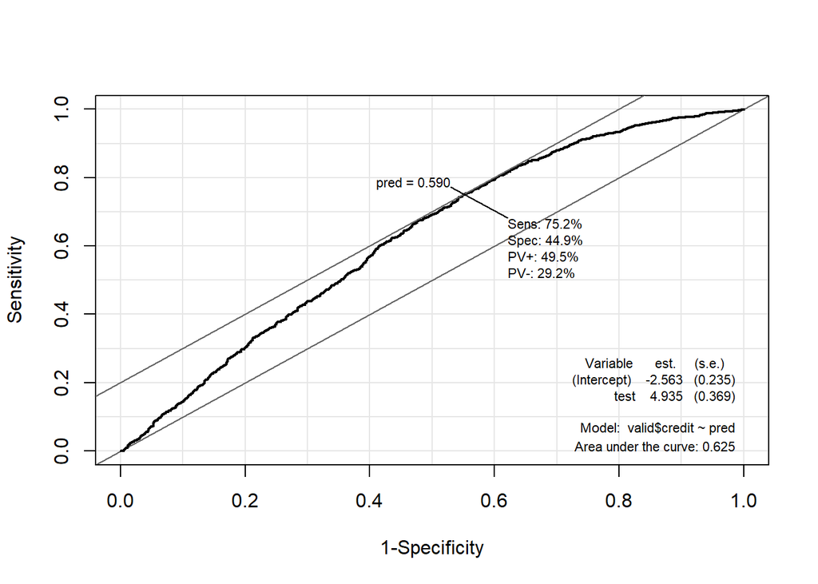

```r
pred = predict(backward, valid, type = 'response')
roc = ROC(test = pred, stat = valid$credit, plot = 'ROC')
```

cut-off point가 0.590일 때 `sensitivity`와 `specificity`의 합이 가장 높다.  
즉, 0.590이 최적의 임계값이다.

## 문제1-7. 위의 ROC curve에서 구한 최적의 임계값을 기준으로 Accuracy와 F1-score를 구하고 값을 저장해두세요.

```r
# 정확성을위해 반올림값이 아닌 최적값 그대로 사용
optimal_idx = which.max(roc$res$sens + roc$res$spec)
optimal_cut = roc$res$pred[optimal_idx]

pred = ifelse(predict(backward, valid, type = 'response') >= optimal_cut, 1, 0)

acc_logistic = Accuracy(pred,valid$credit)
f1_logistic = F1_Score(valid$credit, pred, positive = '1')
```

## 문제1-8. 같은 조건으로 전체 데이터를 다시 로지스틱 회귀 모형을 적합시키고 test 데이터셋에 대해 예측하세요.

```r
fit = glm(backward %>% formula, data = data, family = binomial)
pred_logit = ifelse(predict(fit,test) >= optimal_cut, 1, 0)
```

## [Lasso 로지스틱 회귀]

## 문제2-1. 범주형 변수들이 더미화된 디자인 행렬을 만드세요.

(model.matrix() 사용)

```r
train_x = model.matrix(credit~.,data = train)[,-1]
train_y = train$credit
```

## 문제2-2. CV로 최적의 람다를 찾고 찾은 최적의 람다로 Lasso 로지스틱 회귀 모델을 적합하세요. (seed:123)

```r
set.seed(123)
cv_lasso = cv.glmnet(train_x, train_y, family = 'binomial', alpha = 1)
cv_lasso$lambda.min
```

```
## [1] 0.002466923
```

```r
lasso = glmnet(train_x, train_y, alpha = 1, family = 'binomial',
               lambda = cv_lasso$lambda.min)
```

## 문제2-3. 모델의 회귀계수를 확인하고 회귀계수가 없는 변수들이 있는 이유를 설명해주세요.

```r
lasso %>% coef
```

```
## 48 x 1 sparse Matrix of class "dgCMatrix"
##                                                  s0
## (Intercept)                           -1.109710e-01
## genderM                                .
## carY                                   .
## realityY                              -8.463096e-02
## child_num                              .
## income_total                           3.667395e-07
## income_typePensioner                  -5.996256e-02
## income_typeState servant               .
## income_typeStudent                    -6.919697e-01
## income_typeWorking                    -4.599598e-02
## edu_typeHigher education              -8.289132e-02
## edu_typeIncomplete higher              6.828473e-03
## edu_typeLower secondary                1.874234e-01
## edu_typeSecondary / secondary special  .
## family_typeMarried                     4.198278e-02
## family_typeSeparated                   6.707433e-02
## family_typeSingle / not married        .
## family_typeWidow                      -8.220698e-02
## house_typeHouse / apartment            .
## house_typeMunicipal apartment          9.610403e-02
## house_typeOffice apartment             .
## house_typeRented apartment            -3.911389e-01
## house_typeWith parents                 .
## work_phone1                            .
## phone1                                 .
## email1                                 1.294731e-01
## occyp_typeAccountants                 -1.226406e-01
## occyp_typeCleaning staff               5.824166e-02
## occyp_typeCooking staff                1.038191e-02
## occyp_typeCore staff                   8.889512e-03
## occyp_typeDrivers                      .
## occyp_typeHigh skill tech staff       -9.331368e-02
## occyp_typeHR staff                     6.794996e-01
## occyp_typeIT staff                     .
## occyp_typeLaborers                    -7.586492e-02
## occyp_typeLow-skill Laborers           .
## occyp_typeManagers                     4.005641e-02
## occyp_typeMedicine staff               .
## occyp_typePrivate service staff        .
## occyp_typeRealty agents                1.655408e-02
## occyp_typeSales staff                 -6.945398e-03
## occyp_typeSecretaries                 -1.497738e-02
## occyp_typeSecurity staff               2.162985e-01
## occyp_typeWaiters/barmen staff        -1.119905e-01
## family_size                            .
## begin_month                           -2.191488e-02
## age                                    2.969829e-03
## years_employed                         3.846949e-03
```

`lasso regression`에서 몇몇 회귀계수가 0이 되는 이유는 L1 제약조건 때문인데  
이는 페널티 항에 절대값을 취해주어 `ridge`와는 다르게 제약조건의 영역에 `sharp corner`가 생김  
이 때 RSS의 수준이 `sharp corner`에 닿는다면 그 축의 회귀계수는 0이 됨

## 문제2-4. Validation 데이터를 통해 확률값이 나오도록 예측값을 구하고 이를 사용하여 ROC curve를 그리고 해석해보세요.

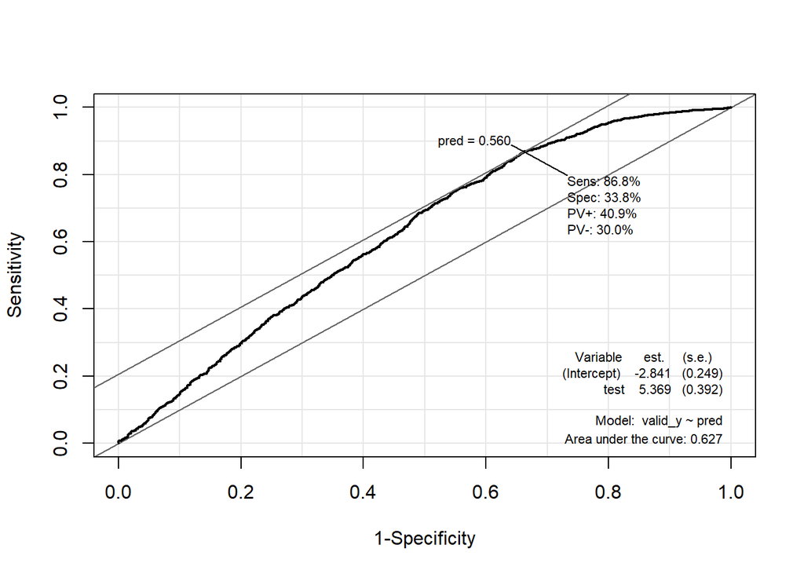

```r
# 더미 변수 생성
valid_x = model.matrix(credit ~ ., data = valid)[,-1]
valid_y = valid$credit

pred = predict(lasso, valid_x, type = 'response')

roc = ROC(test = pred, stat = valid_y, plot = 'ROC')
```

cut-off point가 0.560일 때 `sensitivity`와 `specificity`의 합이 가장 높다.  
즉, 0.560이 최적의 임계값이다.

## 문제2-5. 위의 ROC curve에서 구한 최적의 임계값을 기준으로 Accuracy와 F1-score를 구하고 값을 저장해두세요.

```r
optimal_idx = which.max(roc$res$sens + roc$res$spec)
optimal_cut = roc$res$pred[optimal_idx]

pred = ifelse(predict(lasso, valid_x, type = 'response') >= optimal_cut, 1, 0)

acc_lasso = Accuracy(pred,valid_y)
f1_lasso = F1_Score(valid_y,pred, positive = '1')
```

## 문제2-6. 같은 조건으로 전체 데이터를 다시 Lasso 로지스틱 회귀 모형을 적합시키고 test 데이터셋에 대해 예측하세요.

```r
data_x = model.matrix(credit ~ ., data=data)[,-1]
test_x = model.matrix( ~ ., data=test)[,-1]

fit = glmnet(data_x, data$credit, alpha = 1, family = 'binomial', lambda = cv_lasso$lambda.min)
pred_lasso = ifelse(predict(fit, test_x, type = 'response') >= optimal_cut, 1, 0)
```

## [Ridge 로지스틱 회귀]

## 문제3-1. Lasso 로지스틱 회귀에 사용한 동일한 데이터를 사용하여 CV로 최적의 람다를 찾고 찾은 최적의 람다로 Ridge 로지스틱 회귀 모델을 적합하고 모델의 회귀계수들을 확인하세요. (seed:123)

```r
set.seed(123)
cv_ridge = cv.glmnet(train_x, train_y, family = 'binomial', alpha = 0)
cv_ridge$lambda.min
```

```
## [1] 0.01954994
```

```r
ridge = glmnet(train_x, train_y, alpha = 0, family = 'binomial', lambda = cv_ridge$lambda.min)
ridge %>% coef
```

```
## 48 x 1 sparse Matrix of class "dgCMatrix"
##                                                  s0
## (Intercept)                           -2.516509e-01
## genderM                                2.441746e-03
## carY                                   2.478134e-02
## realityY                              -1.060527e-01
## child_num                              9.864819e-03
## income_total                           3.892876e-07
## income_typePensioner                  -1.384655e-01
## income_typeState servant              -4.760271e-02
## income_typeStudent                    -1.412674e+00
## income_typeWorking                    -8.487536e-02
## edu_typeHigher education              -7.097267e-02
## edu_typeIncomplete higher              9.291204e-02
## edu_typeLower secondary                3.294561e-01
## edu_typeSecondary / secondary special  3.801434e-02
## family_typeMarried                     1.094619e-01
## family_typeSeparated                   1.582184e-01
## family_typeSingle / not married        8.134270e-02
## family_typeWidow                      -7.439656e-02
## house_typeHouse / apartment            5.601976e-02
## house_typeMunicipal apartment          1.838193e-01
## house_typeOffice apartment            -7.702516e-02
## house_typeRented apartment            -3.948876e-01
## house_typeWith parents                 6.093524e-02
## work_phone1                           -2.712860e-02
## phone1                                 1.566700e-02
## email1                                 1.571479e-01
## occyp_typeAccountants                 -1.731625e-01
## occyp_typeCleaning staff               1.241181e-01
## occyp_typeCooking staff                8.274362e-02
## occyp_typeCore staff                   3.494641e-02
## occyp_typeDrivers                     -3.702941e-02
## occyp_typeHigh skill tech staff       -1.493732e-01
## occyp_typeHR staff                     8.828421e-01
## occyp_typeIT staff                    -1.116143e-01
## occyp_typeLaborers                    -1.092634e-01
## occyp_typeLow-skill Laborers           7.152137e-02
## occyp_typeManagers                     5.696642e-02
## occyp_typeMedicine staff               4.582094e-02
## occyp_typePrivate service staff       -1.045296e-01
## occyp_typeRealty agents                1.679363e-01
## occyp_typeSales staff                 -4.987988e-02
## occyp_typeSecretaries                 -1.803809e-01
## occyp_typeSecurity staff               2.629703e-01
## occyp_typeWaiters/barmen staff        -2.441027e-01
## family_size                           -5.798586e-03
## begin_month                           -2.061422e-02
## age                                    4.604552e-03
## years_employed                         4.582587e-03
```

## 문제3-2. Validation 데이터를 통해 확률값이 나오도록 예측값을 구하고 이를 사용하여 ROC curve를 그리고 해석해보세요.

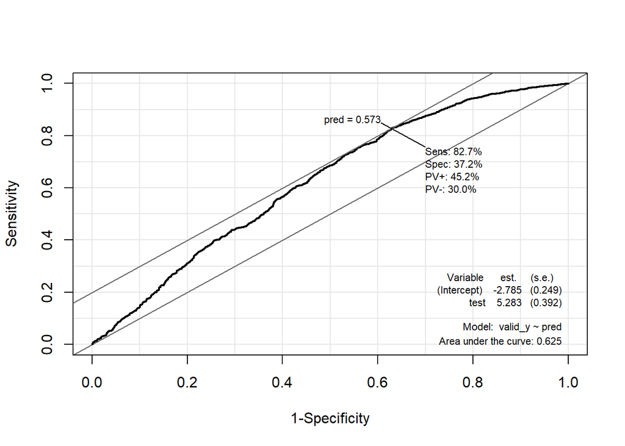

```r
pred = predict(ridge, valid_x, type = 'response')

roc = ROC(test = pred, stat = valid_y, plot = 'ROC')
```

cut-off point가 0.573일 때 `sensitivity`와 `specificity`의 합이 가장 높다.  
즉, 0.573이 최적의 임계값이다.

## 문제3-3. 위의 ROC curve에서 구한 최적의 임계값을 기준으로 Accuracy와 F1-score를 구하고 값을 저장해두세요.

```r
optimal_idx = which.max(roc$res$sens + roc$res$spec)
optimal_cut = roc$res$pred[optimal_idx]

pred = ifelse(predict(ridge, valid_x, type = 'response') >= optimal_cut, 1, 0)

acc_ridge = Accuracy(pred,valid_y)
f1_ridge = F1_Score(valid_y,pred, positive = '1')
```

## 문제3-4. 같은 조건으로 전체 데이터를 다시 Ridge로지스틱 회귀 모형을 적합시키고 test 데이터셋에 대해 예측하세요.

```r
fit = glmnet(data_x, data$credit, alpha = 0, family = 'binomial', lambda = cv_ridge$lambda.min)
pred_ridge = ifelse(predict(fit, test_x, type = 'response') >= optimal_cut, 1, 0)
```

## 문제3-5. 각각 세 모델의 Accuracy값과 F1score 값을 다음과 같이 시각화하고 결과를 해석해보세요.

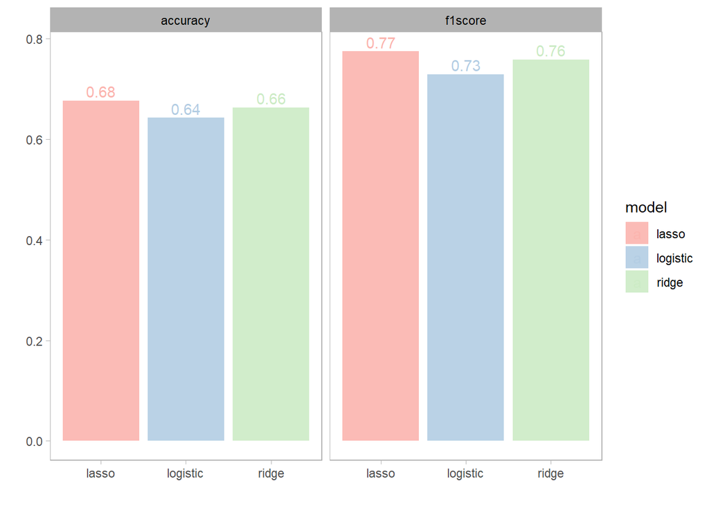

```r
# 데이터 프레임 생성
result = data.frame(acc_ridge,f1_ridge,
                    acc_lasso,f1_lasso,
                    acc_logistic,f1_logistic)

result %<>%
  # 어떤 모델의 어떤 성능지표인지를 나타내는 type열과 그 값인 value열로 나눠줌
  gather(type,value) %>%
  # type열을 다시 모델과 평가지표 2개 열로 나눠줌
  separate(type,into=c('eval','model'),sep='_')

result$eval %<>% factor(labels = c('accuracy','f1score'))

result %>%
  ggplot(aes(x=model, y=value, fill=model)) +
  geom_col(alpha=0.9) +
  geom_text(aes(label = round(value,2), color = model), vjust = -0.3) +

  # 테마 수정
  theme_light() +
  scale_fill_brewer(palette = 'Pastel1') +
  scale_color_brewer(palette = 'Pastel1') +
  labs(x='', y='') +
  theme(panel.grid = element_blank(),
        strip.text = element_text(color = 'black')) +
  facet_wrap(eval~.)
```

일반적인 로지스틱 회귀보다는 페널티 항이 존재하는 `ridge`,`lasso` 로지스틱 회귀가 더 높은 성능을 보여줌.  
그 중에서도 `lasso`가 약간 더 높은 성능을 보임.

# Chapter 3 클러스터링

## 문제1. 환경 내 저장된 데이터를 전부 삭제하고 cluster 패키지의 xclara 데이터를 불러오세요

```r
rm(list=ls())
library(corrplot)
library(cluster)
library(factoextra)
library(gridExtra)

data = xclara
```

## 문제2. 데이터의 상관관계를 확인하고 스케일링을 해주세요. 또한 클러스터링 전에 데이터를 스케일링 해주어야 하는 이유를 적어주세요.

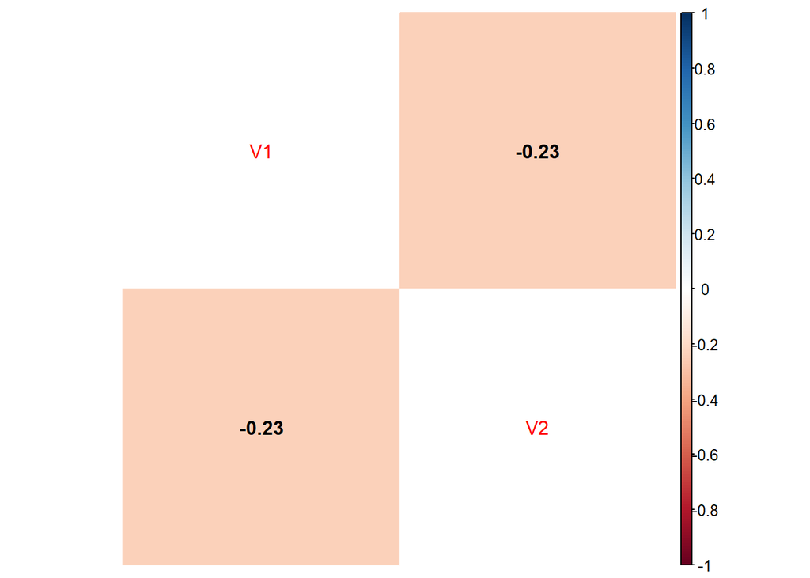

```r
data %>% cor %>% corrplot(method = 'color', diag = F, tl.pos = 'd',
                          addCoef.col = 'black')
```

```r
data %<>% scale
```

kmeans 클러스터링에서는 데이터 간 거리를 이용해 클러스터링을 진행하는데  
이 때 변수 간의 단위가 다르면 데이터 간 거리가 제대로 측정되지 못함  
따라서 거리 계산을 위해 데이터의 스케일링이 필요

## 문제3. Fviz_nbclust 함수로 다음과 같이 시각화한 뒤 적절한 k 값을 선택하고 그 이유를 설명해주세요.

(seed:123)

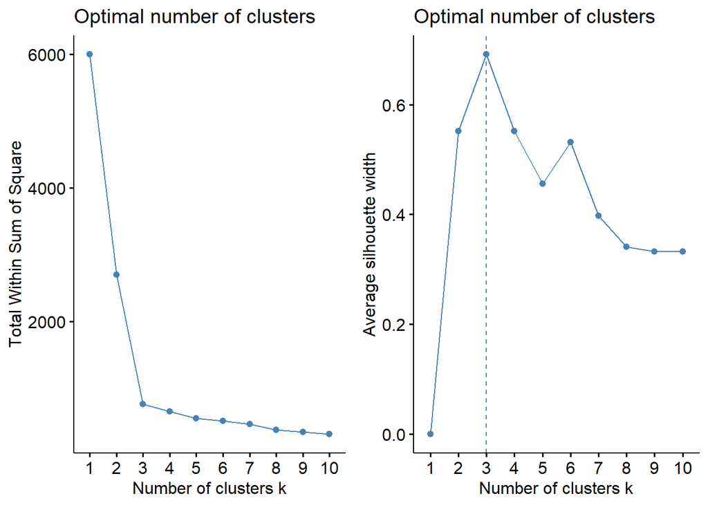

```r
set.seed(123)
grid.arrange(fviz_nbclust(data, kmeans, method = 'w'),
             fviz_nbclust(data, kmeans, method = 's'),
             ncol=2)
```

`k=3`에서 실루앗 값이 가장 높으며 엘보 포인트  
그렇기에 `k=3`이 가장 적절

## 문제4. K-means clustering을 진행하고 다음과 같이 시각화하세요.

(nstart = 1, iter.max = 100)

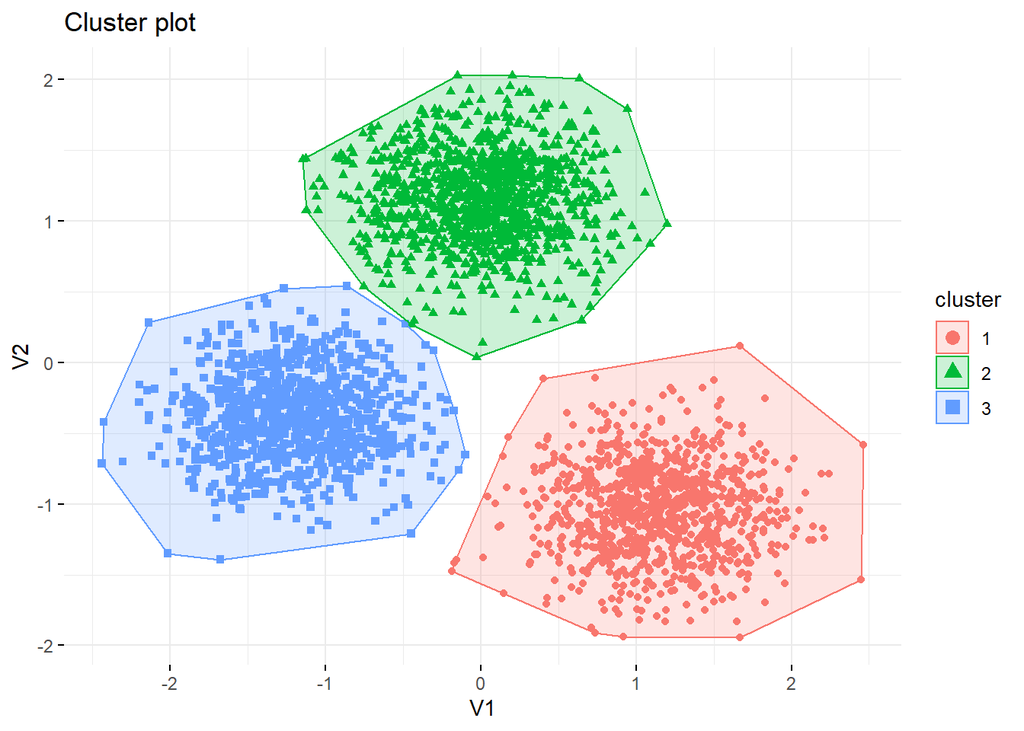

```r
set.seed(9999)
cls = kmeans(data, centers = 3, nstart = 1, iter.max = 100)
fviz_cluster(cls, data=data, geom = 'point',
             ggtheme = theme_minimal())
```

## 문제5. 사용된 변수 V1과 V2에 대해 다음과 같이 클러스터별로 박스 플랏을 시각화하여 비교하세요.

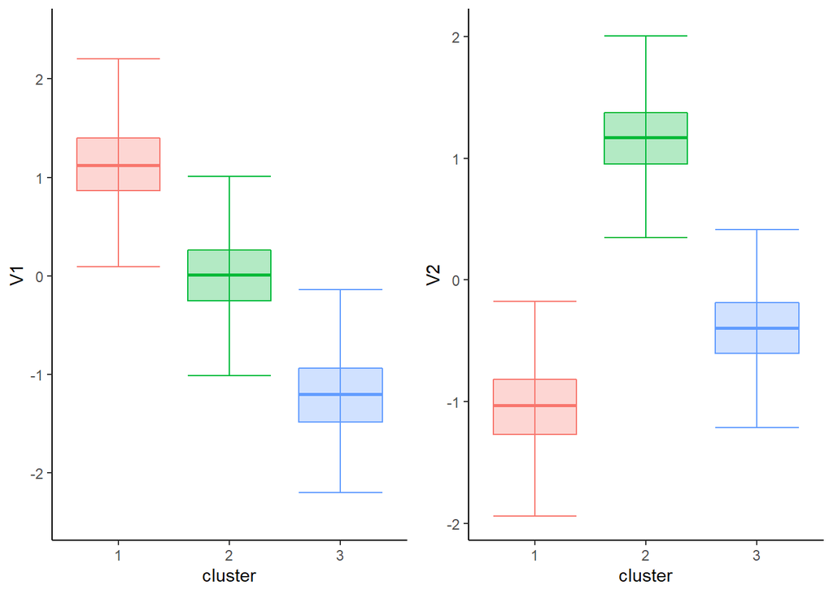

```r
# V1, V2, cluster로 이루어진 데이터 프레임 생성
data_boxplt = data.frame(data, cluster = factor(cls$cluster))

V1box = data_boxplt %>%
  ggplot(aes(x = cluster, y = V1,
             fill = cluster, color = cluster, group = cluster)) +
  geom_boxplot(alpha = 0.3, outlier.shape = NA) + # 이상치 표시 X
  stat_boxplot(geom = 'errorbar') + # 에러 바 표시
  theme_classic() +
  theme(legend.position = 'None')

V2box = data_boxplt %>%
  ggplot(aes(x = cluster, y = V2,
             fill = cluster, color = cluster, group = cluster)) +
  geom_boxplot(alpha = 0.3, outlier.shape = NA) + # 이상치 표시 X
  stat_boxplot(geom = 'errorbar') + # 에러 바 표시
  theme_classic() +
  theme(legend.position = 'None')

grid.arrange(V1box,V2box,ncol=2)
```